# The Rise of Pathways and Key Innovations

Macroevolution · PB 495/595 Plant Evolutionary Biology

George P. Tiley

17 November 2026

## Breaking limits on diversification

- Traits can be associated with diversification rates and the number of species, but their are **constraints** to trait variation
- New spaces and changing environments can create opportunities for diversification, but they have carrying capacities
- Today: Some traits move beyond simple character variation and open new opportunities for success.
  1. What makes an innovation “key”?
  2. What are some examples of key innovations?
  3. Where do new traits come from?

## Learning objectives

By the end you should be able to:

- Define a key innovation, and explain why one that arose once is hard to test with our current tools.
- Tell orthologs, paralogs and ohnologs apart, and describe four fates of a duplicated gene.
- Explain the lag-time hypothesis for a whole-genome duplication predating a radiation.
- Commit three examples of key innovations in angiosperms to memory.
- Compare three competing hypotheses of a contested innovation as exemplified by the origin of nodulation.
- Articulate the case of storage roots as a counterexample to innovation through convergent evolution.

# Key innovations

## The modern synthesis view of key innovations

George G. Simpson (1902 - 1984) *Tempo and mode in evolution* (1944)

Character transitions that promoted the origin and evolution of ecologically and morphologically distinct higher taxa

## A modern synthesis view of key innovations

- **Miller (1949):** “… key adjustments in the morphological and physiological mechanism which are essential to the origin of new major groups”
- **Van Valen (1971):** “A key character, in the adaptive sense, is a structure or element of physiology that makes a taxon more or less committed to a way of life different from, or appreciably more efficient than, that of its ancestors”
- **Levinton (1988):** “key innovation is necessary, but not sufficient for a subsequent radiation”
- **Baum and Larson (1991):** “… a trait that greatly modifies the selective regime of the lineage in which it evolves”
- **Rosenzweig and McCord (1991):** “A key adaptation is a change in the mathematical rule governing a trade-off constraint so that after the change, the trade-off is less severe”
- **Erwin (1992):** “Key innovations characterize particular clades and are both necessary and sufficient to explain diversification within the clade”
- **Heard and Hauser (1995):** “an evolutionary change in individual trait(s) that is causally linked to an increased diversification rate in the resulting clade (for which it is a synapomorphy)”

## A modern view of key innovations

Key innovations **do not** require increased diversification.

## A modern view of key innovations

A key innovation is the evolution of a trait (or set of functionally linked traits) that provides access to novel resources and that, as a result, facilitates an increase in the total species richness of the parent clade (Rabosky 2017).

## Innovation plus opportunity

A **key innovation** may raise that richness by:

1. opening a new adaptive axis of variation
2. raising fitness (potentially at the expense of its sister group)
3. increasing specialization

## Innovation plus opportunity

Is self-incompatibility a key innovation?

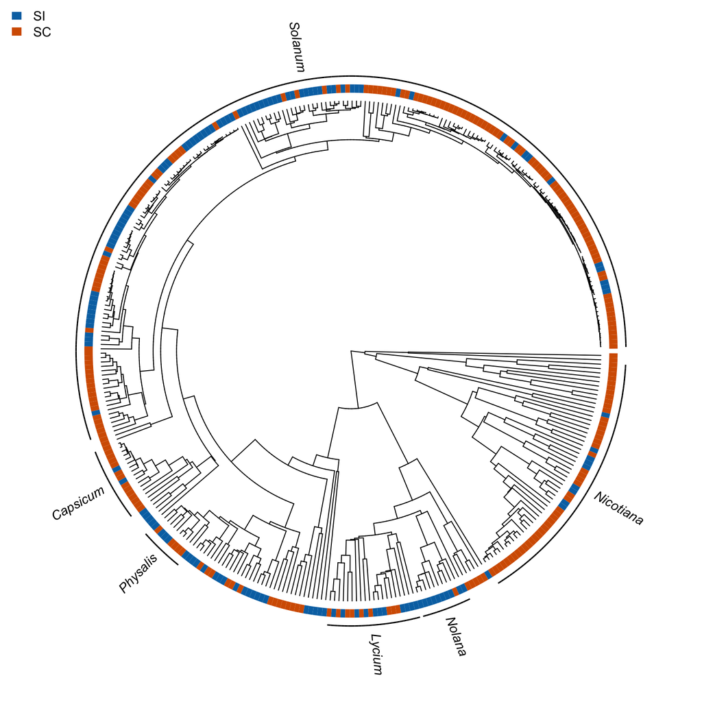

Phylogeny of Solanaceae based on data from (Goldberg et al. 2010)

## It’s rarely one trait

- Reviews of plant radiations find few single-cause stories. More often several traits, a change in the environment and a move to a new region come together along a tree (Donoghue and Sanderson 2015).
- Three words from that paper are useful today:
  - **Synnovation:** a combination of traits that works together.
  - **Confluence:** traits, environment and geography arriving one after another on the same branches.
  - **Depauperon:** a species-poor lineage left behind on the way to a radiation.
- For each case today, we ask three things. How many origins? Which genes? When did the species arrive?

## It’s rarely one trait

A survey of SSE studies:

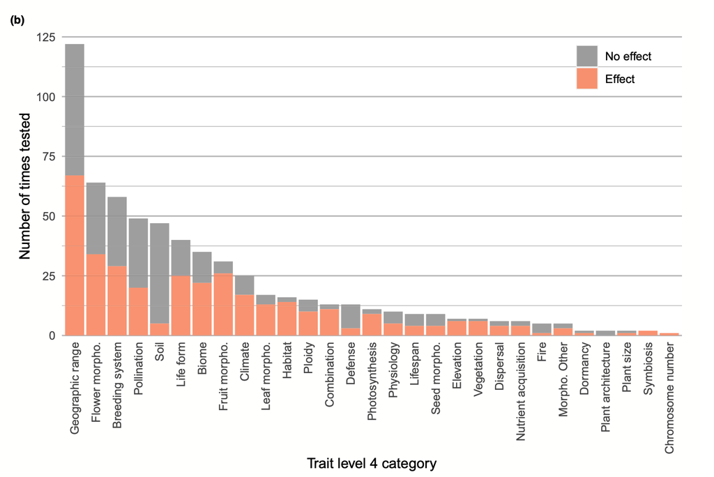

Fig. 2b from Helmstetter et al. (2023). Distribution of SSE studies across angiosperms.

# The challenge of single-origin traits

## Single-origin traits are exciting

- The caution of BiSSE: a trait that changed once can look correlated with anything else that changed in the same clade (Maddison and FitzJohn 2015).
- How does BiSSE handle random single origin traits? A simulation experiment:
  - 150 species. One clade speciates three times faster, for an unknown reason.
  - A neutral trait arises once, on branch A, B, C or D.
  - Does BiSSE support independent $\lambda$ and $\mu$?

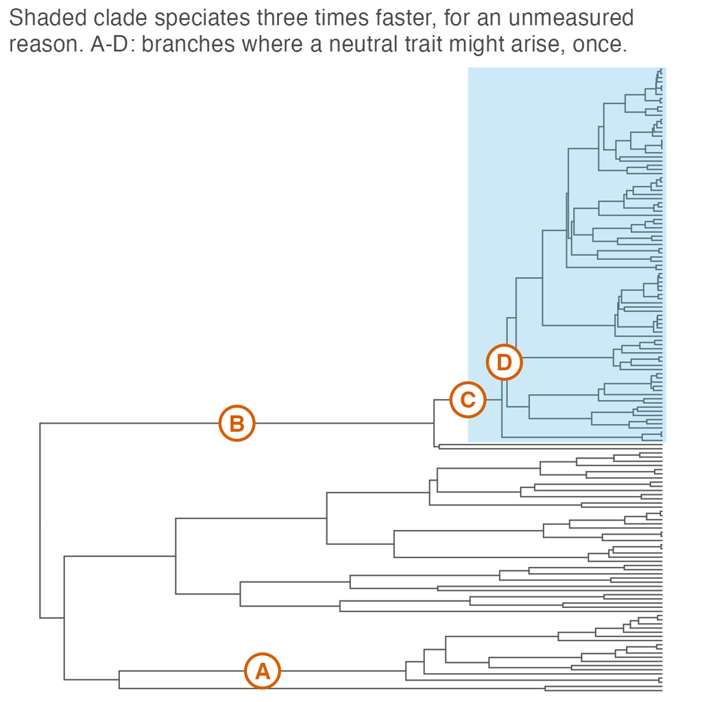

## One origin that does nothing

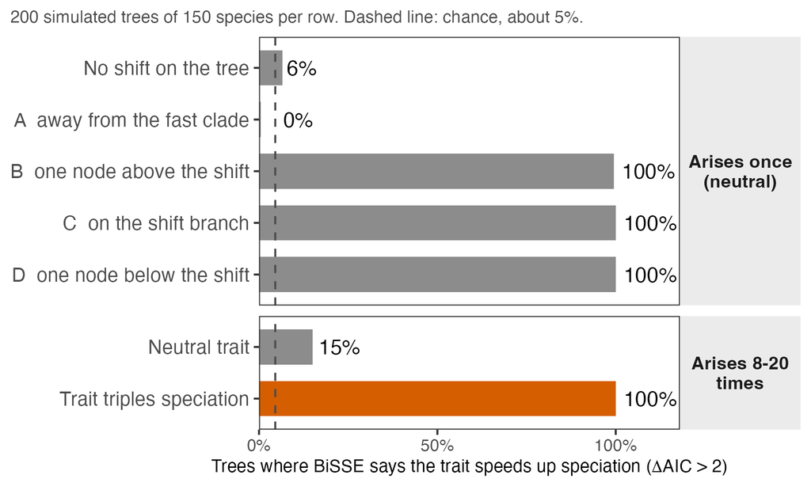

- Far from the shift, BiSSE behaves. Within one node of it, a neutral trait gets the credit every time.
- Row C is also what a single-origin innovation *should* look like.
- With multiple origins, you get statistical power!

## Beyond trees and $r$

The flower arose once, so phylogenies alone cannot help us here. What evidence could persuade you that it mattered for angiosperm diversity?

# Where do new traits come from?

## Genes come in families

If a tree can’t test one origin, we need to understand the genetic basis of the trait.

- Genes that share an ancestor are **homologs**: **orthologs** if split by speciation, **paralogs** if split by duplication.
- A **whole-genome duplication (WGD)** copies every gene at once. Paralogs that come from one are called **ohnologs**.
- WGDs recur across flowering plants, and all share at least one ancient one (Jiao et al. 2011).

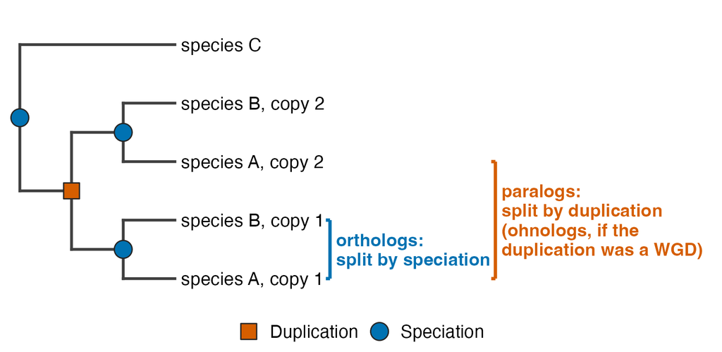

## What happens to a duplicate pair

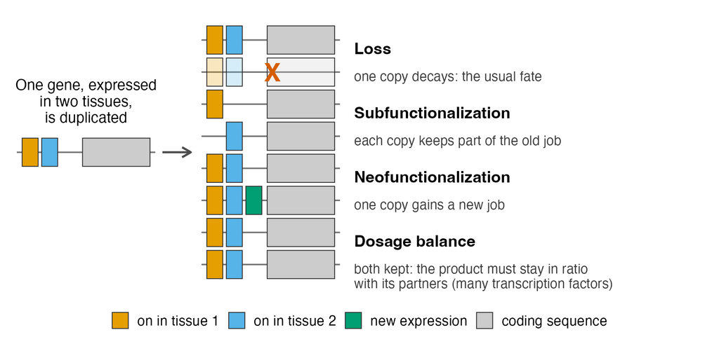

- Most pairs go back to one copy within a few million years (Lynch and Conery 2000).
- Copies can split the old job. Or one can take a new one (Force et al. 1999).
- After a WGD, genes whose products work in complexes are kept more often than others (Maere et al. 2005; Freeling 2009; Birchler and Veitia 2012).

## Becoming diploid again

- A new polyploid has extra sets of chromosomes that can pair with each other. Over time it returns to behaving like a diploid. This is **rediploidization**, or just diploidization (Dodsworth, Chase, and Leitch 2016).
- Along the way genes are lost (**fractionation**), chromosomes rearrange and chromosome numbers fall. What looks like a diploid today was once a polyploid.
- Often considered fast, but many unknowns.

## The lag-time model

- Many big clades have a WGD near their base: Brassicaceae, Poaceae, Asteraceae, Fabaceae, Solanaceae (Schranz, Mohammadin, and Edger 2012).
- Each has **depauperons** that share the same WGD, and the radiation came later.
- Testing the lag-time model has not really been done becuase what is the expected waiting time following WGD? (Clark and Donoghue 2018)
- Is the lag due to waiting on a new environment?

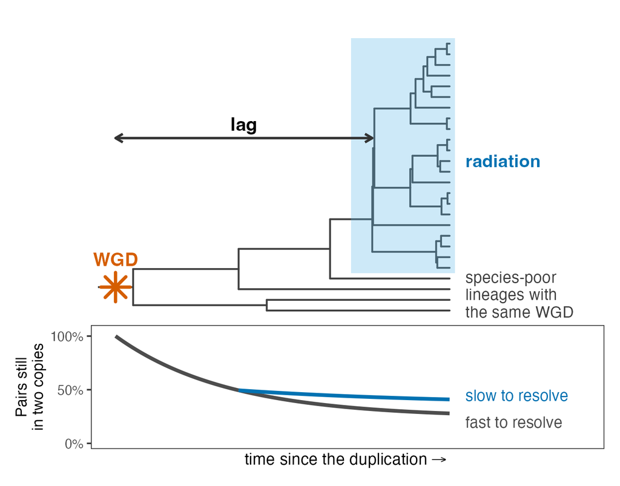

## Five case studies

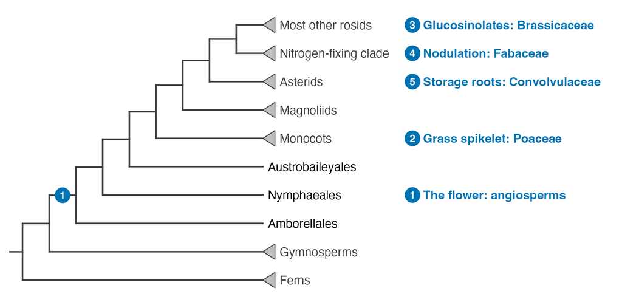

Simplified phylogeny based on many transcriptomes(One Thousand Plant Transcriptomes Initiative 2019)

For each case: 1) how many origins, 2) which genes, 3)when did the species arrive?

# The flower

## Early-diverging angiosperms

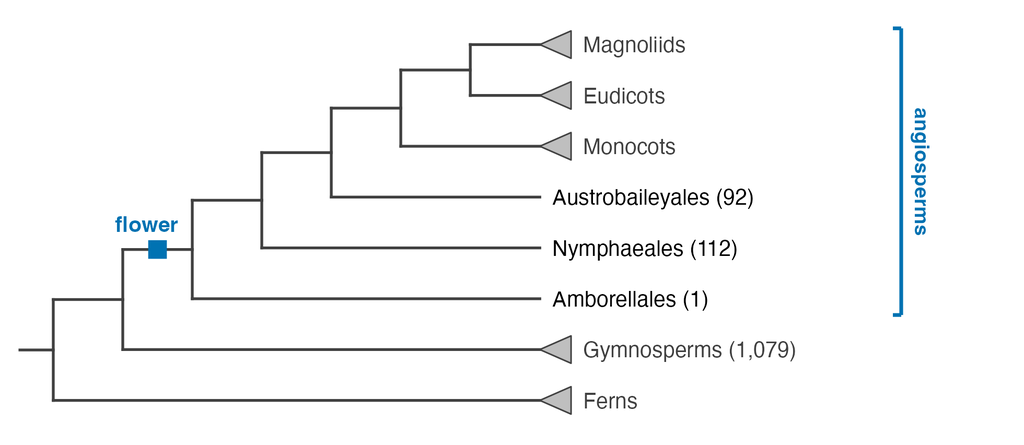

## One origin, about 300,000 species

- We can reconstruct the ancestral flower from living species. It was bisexual and radially symmetric, with whorls of undifferentiated tepals, stamens in threes, and more than five separate carpels in a spiral (Sauquet et al. 2017).
- “The flower” is a bundle: carpels enclosing the ovules, both sexes on one axis, a perianth. Which part is the innovation? Which word from earlier fits a bundle like this?

## One origin, about 300,000 species

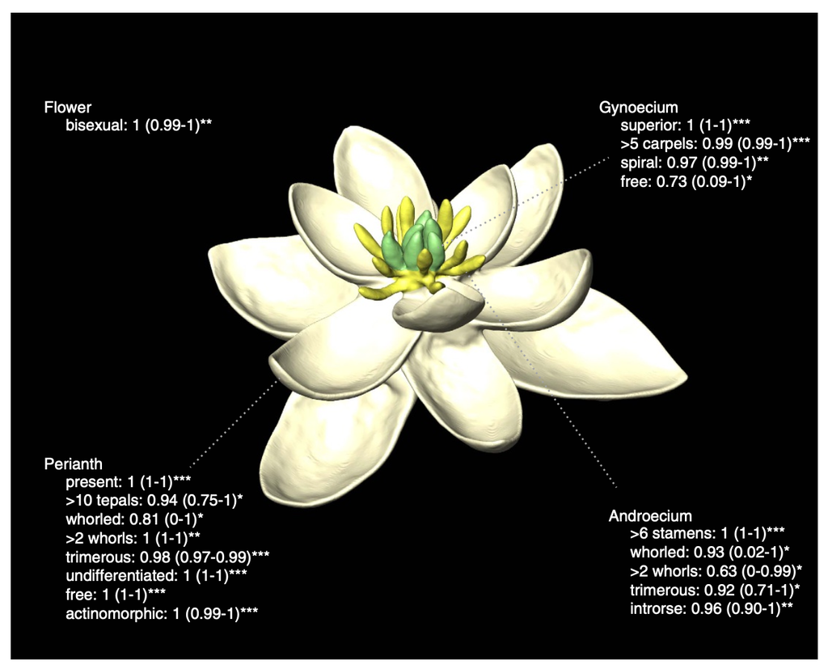

Fig. 1 from Sauquet et al. (2017)

## Floral organ identity is determined by paralogs

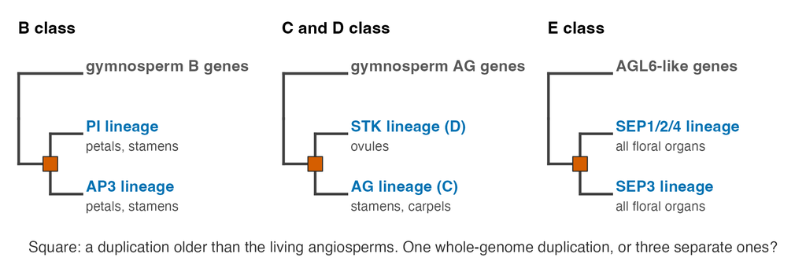

- Floral organs are specified by combinations of MADS-box transcription factors. These bind DNA as four-protein complexes (Coen and Meyerowitz 1991; Theißen, Melzer, and Rümpler 2016).
- Each class owes its two lineages to a duplication older than the living angiosperms (Kim et al. 2004; Kramer, Jaramillo, and Di Stilio 2004; Zahn et al. 2005).

## Floral organ identity is determined by paralogs

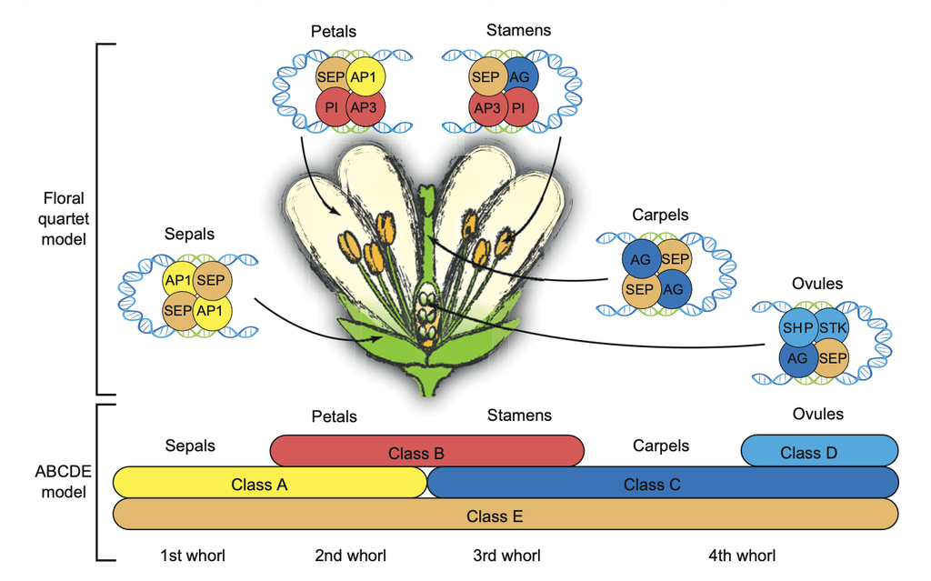

Fig. 1 from Theißen, Melzer, and Rümpler (2016). Floral tissue expression of MADS-box genes.

## Floral organ identity is determined by paralogs

| Whorl | Organ | Gene classes |
| --- | --- | --- |
| 1 | Sepals | A + E |
| 2 | Petals | A + B + E |
| 3 | Stamens | B + C + E |
| 4 | Carpels | C + E |
| Inside 4 | Ovules | C + D + E |

Does our WGD make a prediction for the retention of these MADS-box gene duplicates?

## Was it a whole-genome duplication?

- **Pre-angiosperm and pre-seed plant hypothesis:** dating almost 800 gene trees gave two bursts of duplication, one before the seed plants (ζ) and one before the angiosperms (ε) (Jiao et al. 2011). The *Amborella* genome paper also reported a duplication older than the living angiosperms (Amborella Genome Project 2013).
- **Pre-seed plant only:** the two bursts are senstative to clock model choice (Ruprecht et al. 2017). Recent analysis of dosage-sensitive genes, which should have biased retention from a WGD, show one burst before the seed plants and none on the angiosperm stem (Shi and Van de Peer 2026).

Regardless of the exact mechanism, there was a lag following WGD.

## It took time for variation for the species to follow

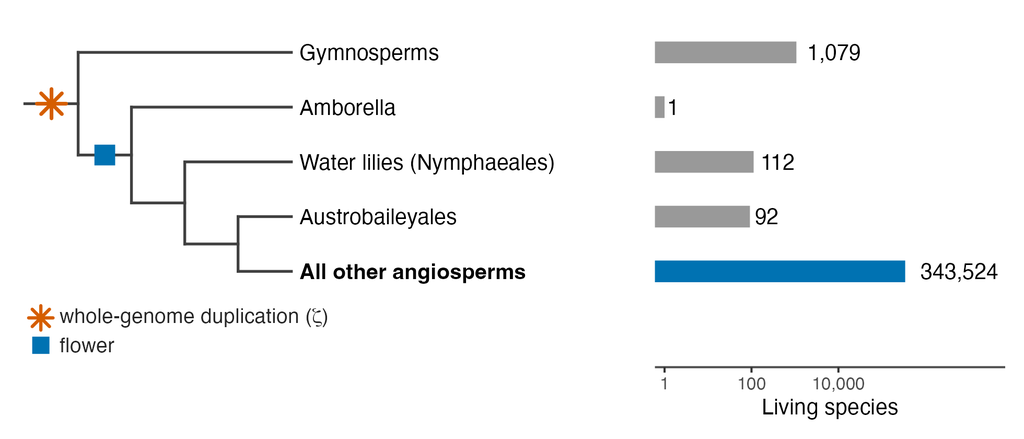

- The early-diverging angiosperms are depauperons
- **Origins:** one. **Genes:** old MADS-box duplicates. **Species:** later.

# The grass spikelet

## Grasses!

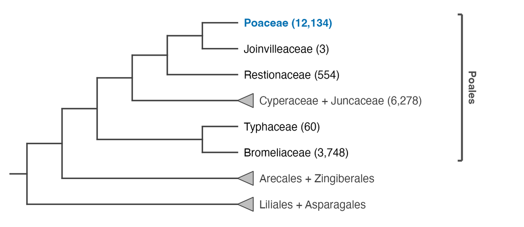

- Grasses (Poaceae) are in the order Poales with the sedges (Cyperaceae), rushes (Juncaceae) and bromeliads.
- Their sister family is Joinvilleaceae, which has three species.

## A new unit of reproduction

- A **spikelet** is a short axis with one or more tiny flowers, or florets. Each is wrapped in two bracts, the lemma and palea. Two more bracts, the glumes, sit at the base (Kellogg 2001).
- Petals are reduced to small lodicules that push the floret open (Whipple et al. 2007).
- The spikelet, with its awned lemma, is also the unit of dispersal. And it’s what we harvest.
- Grasses have 12,134 species. They grow in almost every ecosystem that has flowering plants and dominate many. The explanation offered is a syndrome of traits for dispersing, establishing, persisting and changing the habitat (Linder et al. 2018). Another synnovation.

## A new unit of reproduction

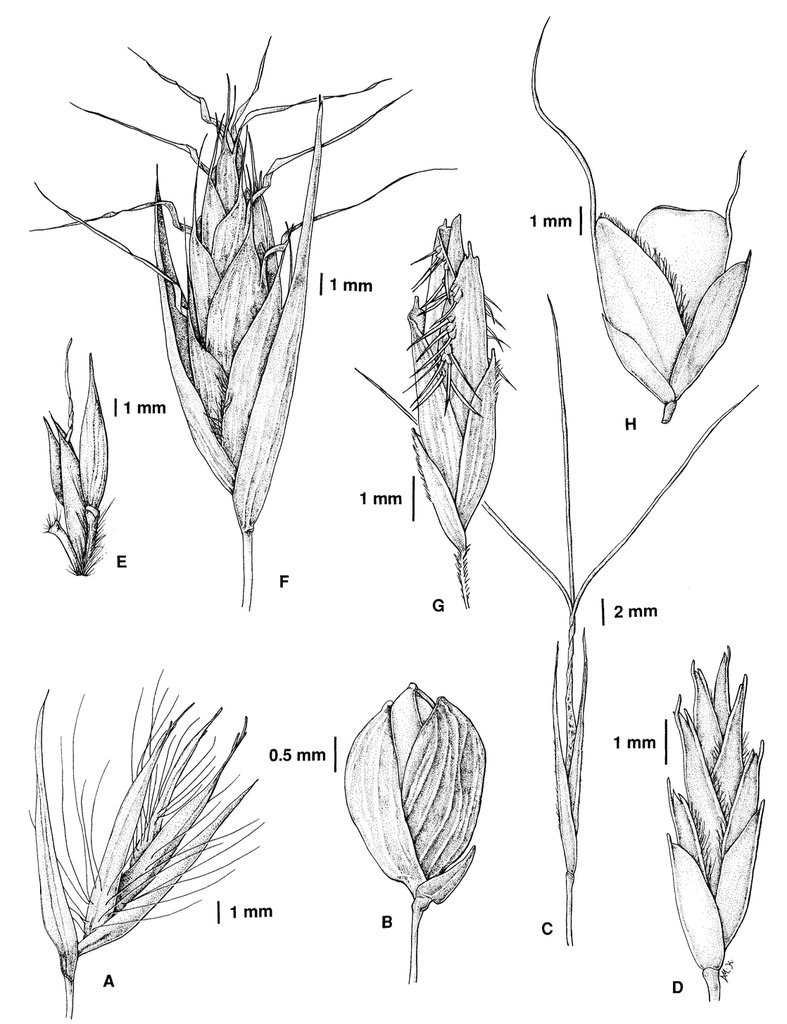

Fig. 5 from Barker et al. (2001). Examples of spikelets.

## Did the spikelet raise species richness?

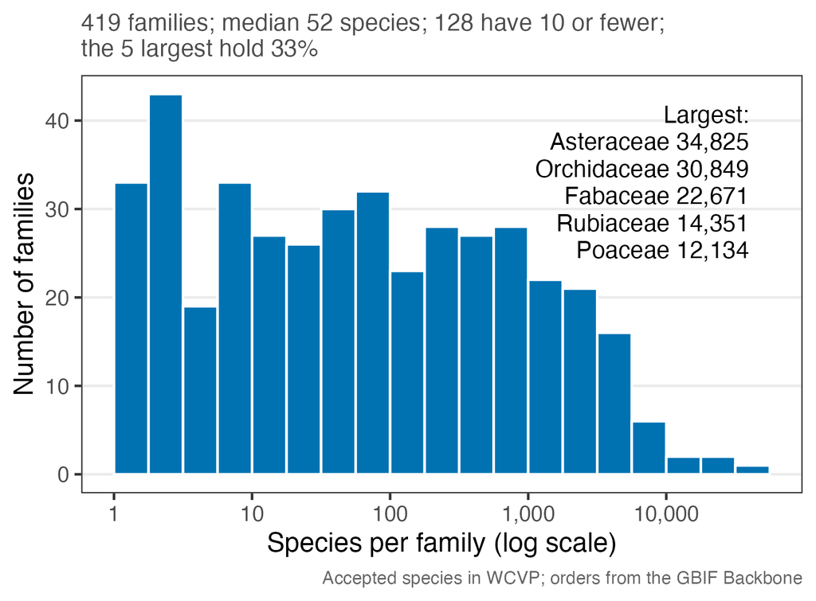

Histogram of species per angiosperm family on a log scale.

## A duplication at the base of the grasses

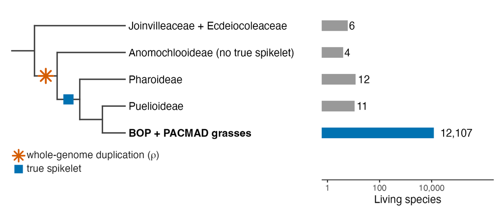

- All grasses share a WGD called ρ, about 98 million years old (Paterson, Bowers, and Chapman 2004; McKain et al. 2016; Ma et al. 2021).
- Pharoideae and Puelioideae are depauperons with true spikelets.

## Which copies were kept?

- *FRIZZY PANICLE* is not a MADS-box gene, but still a transcription factor involved in spikelet development.

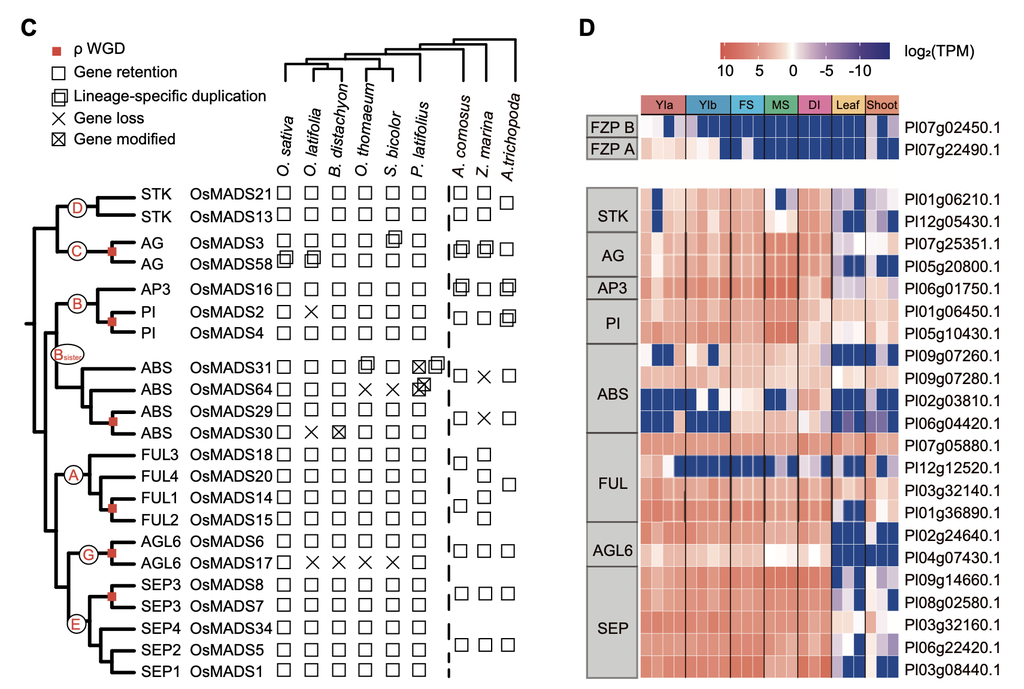

Fig. 5 from Ma et al. (2021). Expression of $\rho$-derived MADS-box genes in *Pharus*.

# A pathway: glucosinolates

## Brassicaeae - that cruciferous taste

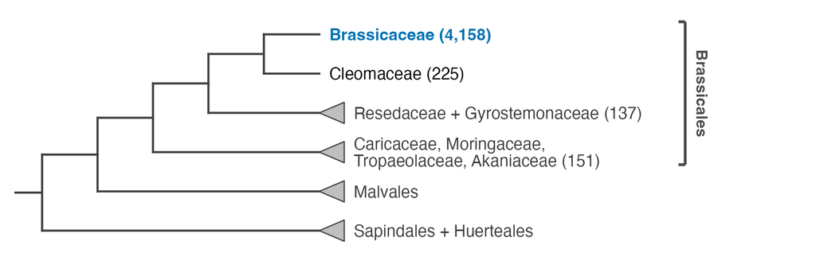

- The whole order makes glucosinolates, including papaya (Caricaceae).

## Chemical diversity: an arms race with the hungry caterpillar

- **Glucosinolates** are the defenses of the Brassicales, about 90 million years old. Pierid butterflies answered with a detoxifying protein, and both sides kept escalating (Ehrlich and Raven 1964; Wheat et al. 2007; Edger et al. 2015).
- The plants escalated in steps:
  1. First, glucosinolates made from phenylalanine.
  2. After a WGD (At-β): from tryptophan too, using both duplicates.
  3. Later: from methionine, after more duplication.
  4. Brassicaceae: the most diverse set, after another WGD (At-α) and many tandem duplications.
- Diversification rates shift near these steps, in plants and butterflies.

## Chemical diversity: an arms race with the hungry caterpillar

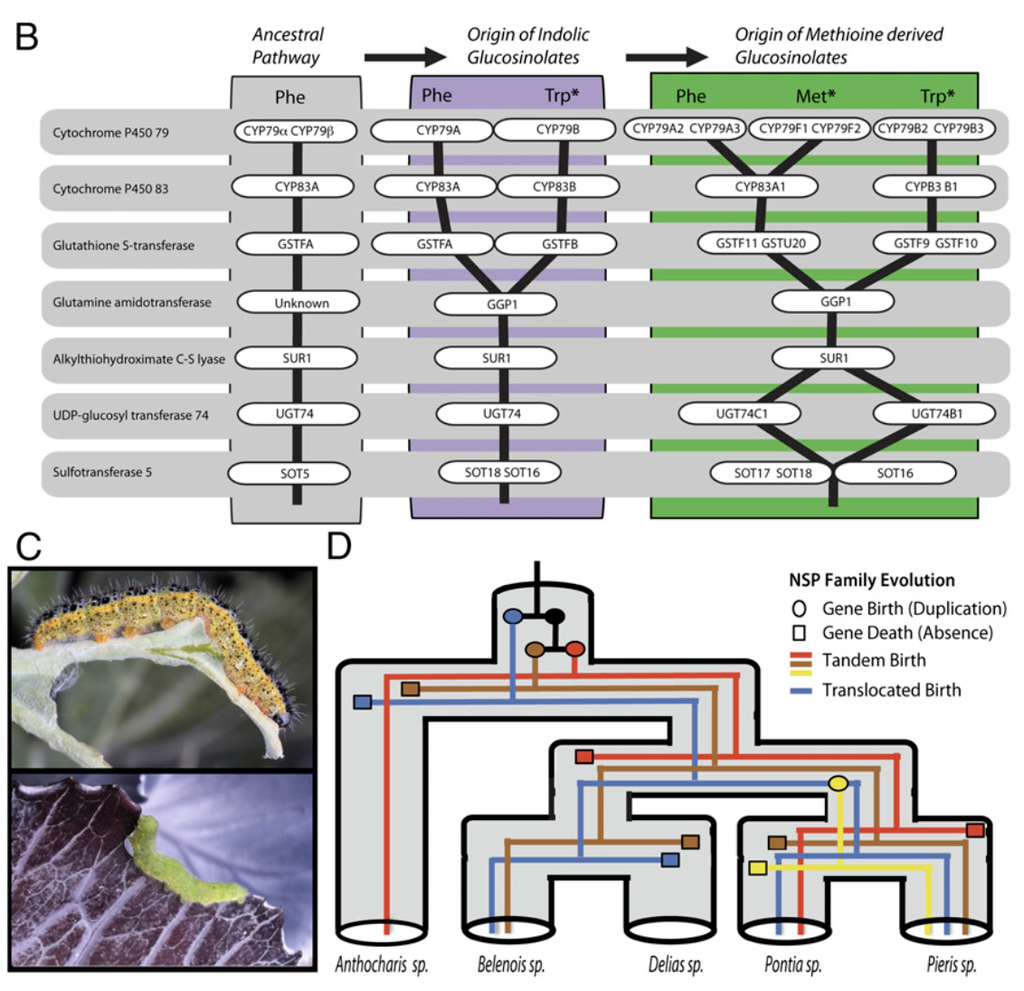

Fig. 2 from Edger et al. (2015). Duplication of butterfly gut enzymes in response to increasing glucosinolate diversity

## Duplicates built the pathway, and the species came later

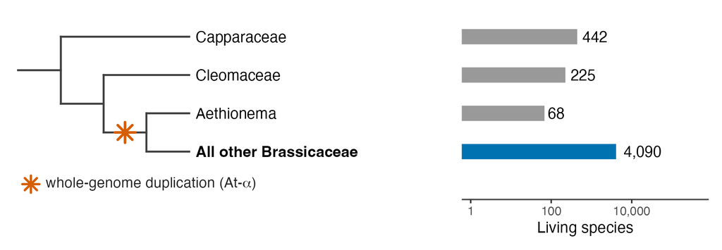

- In *Arabidopsis*, about half of the glucosinolate genes are ohnologs from At-α, compared to 22% of all genes(Hofberger et al. 2013).
- **Origins:** Ancestral pathway with chemical diversity built in steps.
- **Genes:** ohnologs from two WGDs, plus tandem copies.
- **Species:** rate shifts near each step, with a lag.

# Nodulation

## Fabaceae are part of a nitrogen-fixing clade

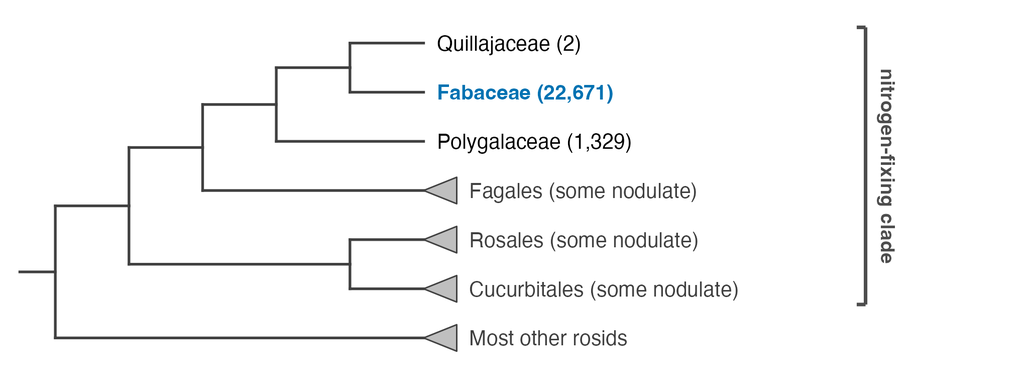

- Nodules are present in four orders, but most prevalent in Fabaceae.

## One clade, scattered nodules

Nodules are a trait that is variable within a clade and may have arisen many times.

- In root **nodules**, plants house bacteria that fix nitrogen.
- In legumes, nodules occur in two of six subfamilies, which hold 94% of the species (Legume Phylogeny Working Group 2017).
- A key innovation for legumes?

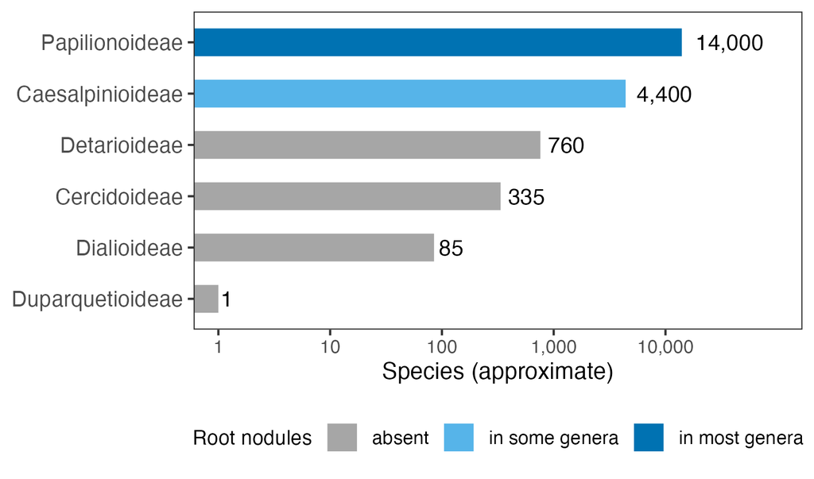

## Three ways to read the same tips

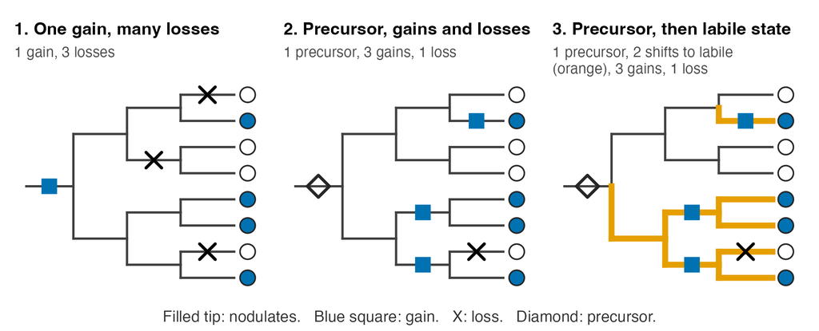

1. **One gain, many losses.** Non-nodulating relatives carry broken or missing copies of genes that nodulation needs, such as *NIN* (Griesmann et al. 2018; Velzen et al. 2018).
2. **A precursor, then gains and losses.** One hidden change made it possible. The symbiosis came and went later (Soltis et al. 1995; Werner et al. 2014).
3. **A precursor, then a labile state.** 16 gains and 10 losses on a tree of 12,768 species (Kates et al. 2024).

## Where do duplicates come in?

- Nodulation signaling was borrowed from the much older symbiosis with mycorrhizal fungi (Parniske 2008).
- The papilionoid legumes share a WGD about 58 million years old. It gave pairs such as *NFP*/*LYR1* and *ERN1*/*ERN2*, where one copy now works in nodules and the other in mycorrhizae (Young et al. 2011). About a quarter of the pairs survive, many in symbiosis functions (Li et al. 2013).
- Does that make the WGD the cause of nodulation? Nodules also occur outside the papilionoids. Non-nodulating papilionoids share the duplication. Non-nodulating subfamilies have WGDs of their own (Cannon et al. 2015; Koenen et al. 2021; Zhao et al. 2021).
- **Origins:** one, or 16. **Genes:** an old pathway borrowed; a later WGD refined it. **Species:** no clear link.

# Storage roots: a counter-example

## Convolvulaceae - sweetpotato, ornamentals, and horrible weeds

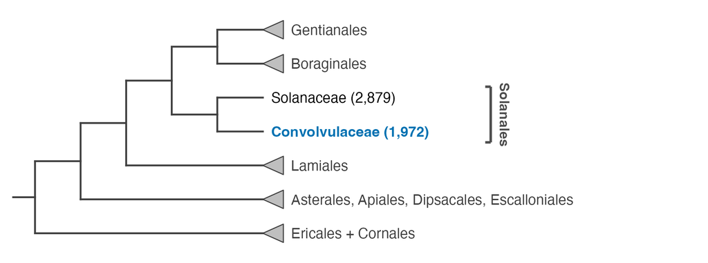

- Convolvulaceae are the sister to Solanaceae, and together form the order Solanales.
- Sweetpotato and potato are relatives are not so different but very different starch storage mechanisms.

## Sweetpotato is not the only storage root in Convolvulaceae

Nodulation borrowed an old pathway, and a WGD refined it. Did storage roots need new genes?

- A **storage root** is a root swollen with starch.
- More than 60 *Ipomoea* species have storage roots, which evolved independently and before people grew any (Muñoz-Rodríguez et al. 2019).
- Across morning glories they were gained at least ten times. Or the ancestor had them and most lineages lost them. The data can’t yet say (Eserman, Jarret, and Leebens-Mack 2018; Eserman et al. 2014).

## Sweetpotato is not the only storage root in Convolvulaceae

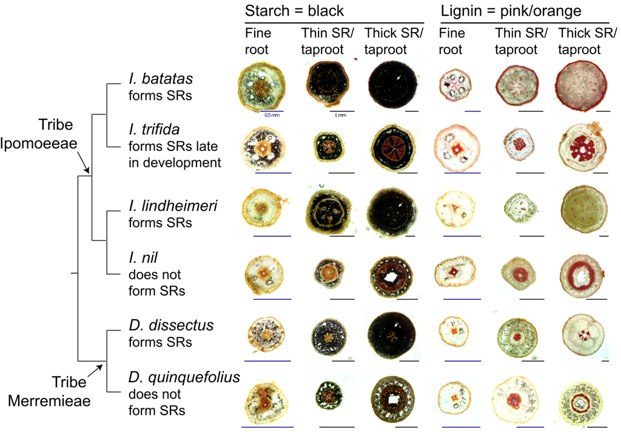

Figure from Eserman, Jarret, and Leebens-Mack (2018)

# Key takeaways

## Five cases, side by side

| Case | Origins | Genes | Species |
| --- | --- | --- | --- |
| Flower | one | old MADS-box duplicates; a WGD is disputed | about 300,000 |
| Spikelet | one | ρ ohnologs, MADS-box pairs among them | 12,000 |
| Glucosinolates | one pathway, built in steps | ohnologs from two WGDs, plus tandem copies | 4,000 |
| Nodulation | one, or 16 | an old pathway borrowed; a later WGD refined it | NA |
| Storage roots | at least ten gains or losses | same starch synthesis orthologs | NA |

# Key takeaways

## Summary

- A key innovation provides access to novel resources. Should increase richness but not necessarily diversification.
- One origin is one data point. SSE models will not be reliable here.
- Duplicate genes are the first suspect for interesting traits. Can we map function to ohnologs?
- Radiations often lag behind duplications.
- The flower, the spikelet and glucosinolates were built with old duplicates, and each radiation has characteristic depauperons.
- Duplication is not everything, and some traits such as nodulation are debated and some like storage roots are cases of convergent evoluition.

## Coming up

- **Thursday (Nov 19), duplication and polyploidy revisited:** how do we know a genome duplicated 100 million years ago? And why can’t we agree about ε?
- **Nov 24, the genome as a trait:** computer activity and discussion. Do genome sizes place limits on evolution?

# References

Amborella Genome Project. 2013. “The Amborella Genome and the Evolution of Flowering Plants.” *Science* 342 (6165): 1241089. https://doi.org/10.1126/science.1241089.

Barker, Nigel P, Lynn G Clark, Jerrold I Davis, Melvin R Duvall, Gerald F Guala, Catherine Hsiao, Elizabeth A Kellogg, H Peter Linder, Roberta J Mason-Gamer, et al. 2001. “Phylogeny and Subfamilial Classification of the Grasses (Poaceae).” *Annals of the Missouri Botanical Garden*, 373–457.

Birchler, James A., and Reiner A. Veitia. 2012. “Gene Balance Hypothesis: Connecting Issues of Dosage Sensitivity Across Biological Disciplines.” *Proceedings of the National Academy of Sciences* 109 (37): 14746–53. https://doi.org/10.1073/pnas.1207726109.

Cannon, Steven B., Michael R. McKain, Alex Harkess, Matthew N. Nelson, Sudhansu Dash, Michael K. Deyholos, Yanhui Peng, et al. 2015. “Multiple Polyploidy Events in the Early Radiation of Nodulating and Nonnodulating Legumes.” *Molecular Biology and Evolution* 32 (1): 193–210. https://doi.org/10.1093/molbev/msu296.

Christenhusz, Maarten J. M., and James W. Byng. 2016. “The Number of Known Plants Species in the World and Its Annual Increase.” *Phytotaxa* 261 (3): 201–17. https://doi.org/10.11646/phytotaxa.261.3.1.

Clark, James W., and Philip C. J. Donoghue. 2018. “Whole-Genome Duplication and Plant Macroevolution.” *Trends in Plant Science* 23 (10): 933–45. https://doi.org/10.1016/j.tplants.2018.07.006.

Coen, Enrico S., and Elliot M. Meyerowitz. 1991. “The War of the Whorls: Genetic Interactions Controlling Flower Development.” *Nature* 353 (6339): 31–37. https://doi.org/10.1038/353031a0.

Dodsworth, Steven, Mark W. Chase, and Andrew R. Leitch. 2016. “Is Post-Polyploidization Diploidization the Key to the Evolutionary Success of Angiosperms?” *Botanical Journal of the Linnean Society* 180 (1): 1–5. https://doi.org/10.1111/boj.12357.

Donoghue, Michael J., and Michael J. Sanderson. 2015. “Confluence, Synnovation, and Depauperons in Plant Diversification.” *New Phytologist* 207 (2): 260–74. https://doi.org/10.1111/nph.13367.

Edger, Patrick P., Hanna M. Heidel-Fischer, Michaël Bekaert, Jadranka Rota, Gernot Glöckner, Adrian E. Platts, David G. Heckel, et al. 2015. “The Butterfly Plant Arms-Race Escalated by Gene and Genome Duplications.” *Proceedings of the National Academy of Sciences* 112 (27): 8362–66. https://doi.org/10.1073/pnas.1503926112.

Ehrlich, Paul R., and Peter H. Raven. 1964. “Butterflies and Plants: A Study in Coevolution.” *Evolution* 18 (4): 586–608. https://doi.org/10.1111/j.1558-5646.1964.tb01674.x.

Eserman, Lauren A., Robert L. Jarret, and James H. Leebens-Mack. 2018. “Parallel Evolution of Storage Roots in Morning Glories (Convolvulaceae).” *BMC Plant Biology* 18 (1): 95. https://doi.org/10.1186/s12870-018-1307-4.

Eserman, Lauren A., George P. Tiley, Robert L. Jarret, Jim H. Leebens-Mack, and Richard E. Miller. 2014. “Phylogenetics and Diversification of Morning Glories (Tribe Ipomoeeae, Convolvulaceae) Based on Whole Plastome Sequences.” *American Journal of Botany* 101 (1): 92–103. https://doi.org/10.3732/ajb.1300207.

Force, Allan, Michael Lynch, F Bryan Pickett, Angel Amores, Yi-lin Yan, and John Postlethwait. 1999. “Preservation of Duplicate Genes by Complementary, Degenerative Mutations.” *Genetics* 151 (4): 1531–45. https://doi.org/10.1093/genetics/151.4.1531.

Freeling, Michael. 2009. “Bias in Plant Gene Content Following Different Sorts of Duplication: Tandem, Whole-Genome, Segmental, or by Transposition.” *Annual Review of Plant Biology* 60 (1): 433–53. https://doi.org/10.1146/annurev.arplant.043008.092122.

Goldberg, Emma E., Joshua R. Kohn, Russell Lande, Kelly A. Robertson, Stephen A. Smith, and Boris Igić. 2010. “Species Selection Maintains Self-Incompatibility.” *Science* 330 (6003): 493–95. https://doi.org/10.1126/science.1194513.

Griesmann, Maximilian, Yue Chang, Xin Liu, Yue Song, Georg Haberer, Matthew B. Crook, Benjamin Billault-Penneteau, et al. 2018. “Phylogenomics Reveals Multiple Losses of Nitrogen-Fixing Root Nodule Symbiosis.” *Science* 361 (6398): eaat1743. https://doi.org/10.1126/science.aat1743.

Helmstetter, Andrew J., Rosana Zenil-Ferguson, Hervé Sauquet, Sarah P. Otto, Marcos Méndez, Mario Vallejo-Marin, Jürg Schönenberger, et al. 2023. “Trait-Dependent Diversification in Angiosperms: Patterns, Models and Data.” *Ecology Letters* 26 (4): 640–57. https://doi.org/10.1111/ele.14170.

Hofberger, Johannes A., Eric Lyons, Patrick P. Edger, J. Chris Pires, and M. Eric Schranz. 2013. “Whole Genome and Tandem Duplicate Retention Facilitated Glucosinolate Pathway Diversification in the Mustard Family.” *Genome Biology and Evolution* 5 (11): 2155–73. https://doi.org/10.1093/gbe/evt162.

Hoshino, Atsushi, Vasanthan Jayakumar, Eiji Nitasaka, Atsushi Toyoda, Hideki Noguchi, Takehiko Itoh, Tadasu Shin-I, et al. 2016. “Genome Sequence and Analysis of the Japanese Morning Glory Ipomoea Nil.” *Nature Communications* 7 (1): 13295. https://doi.org/10.1038/ncomms13295.

Jiao, Yuannian, Norman J. Wickett, Saravanaraj Ayyampalayam, et al. 2011. “Ancestral Polyploidy in Seed Plants and Angiosperms.” *Nature* 473 (7345): 97–100. https://doi.org/10.1038/nature09916.

Kates, Heather R., Brian C. O’Meara, Raphael LaFrance, Gregory W. Stull, Euan K. James, Shui-Yin Liu, Qin Tian, et al. 2024. “Shifts in Evolutionary Lability Underlie Independent Gains and Losses of Root-Nodule Symbiosis in a Single Clade of Plants.” *Nature Communications* 15 (1): 4262. https://doi.org/10.1038/s41467-024-48036-3.

Kellogg, Elizabeth A. 2001. “Evolutionary History of the Grasses.” *Plant Physiology* 125 (3): 1198–1205. https://doi.org/10.1104/pp.125.3.1198.

Kim, Sangtae, Mi-Jeong Yoo, Victor A. Albert, James S. Farris, Pamela S. Soltis, and Douglas E. Soltis. 2004. “Phylogeny and Diversification of B-Function MADS-Box Genes in Angiosperms: Evolutionary and Functional Implications of a 260-Million-Year-Old Duplication.” *American Journal of Botany* 91 (12): 2102–18. https://doi.org/10.3732/ajb.91.12.2102.

Koenen, Erik J M, Dario I Ojeda, Freek T Bakker, Jan J Wieringa, Catherine Kidner, Olivier J Hardy, R Toby Pennington, Patrick S Herendeen, Anne Bruneau, and Colin E Hughes. 2021. “The Origin of the Legumes Is a Complex Paleopolyploid Phylogenomic Tangle Closely Associated with the Cretaceous–Paleogene (K–Pg) Mass Extinction Event.” *Systematic Biology* 70 (3): 508–26. https://doi.org/10.1093/sysbio/syaa041.

Kramer, Elena M, M Alejandra Jaramillo, and Verónica S Di Stilio. 2004. “Patterns of Gene Duplication and Functional Evolution During the Diversification of the AGAMOUS Subfamily of MADS Box Genes in Angiosperms.” *Genetics* 166 (2): 1011–23. https://doi.org/10.1093/genetics/166.2.1011.

Legume Phylogeny Working Group. 2017. “A New Subfamily Classification of the Leguminosae Based on a Taxonomically Comprehensive Phylogeny.” *Taxon* 66 (1): 44–77. https://doi.org/10.12705/661.3.

Li, Qi-Gang, Li Zhang, Chun Li, Jim M. Dunwell, and Yuan-Ming Zhang. 2013. “Comparative Genomics Suggests That an Ancestral Polyploidy Event Leads to Enhanced Root Nodule Symbiosis in the Papilionoideae.” *Molecular Biology and Evolution* 30 (12): 2602–11. https://doi.org/10.1093/molbev/mst152.

Linder, H. P., Caroline E. R. Lehmann, Sally Archibald, Colin P. Osborne, and David M. Richardson. 2018. “Global Grass (Poaceae) Success Underpinned by Traits Facilitating Colonization, Persistence and Habitat Transformation.” *Biological Reviews* 93 (2): 1125–44. https://doi.org/10.1111/brv.12388.

Lynch, Michael, and John S. Conery. 2000. “The Evolutionary Fate and Consequences of Duplicate Genes.” *Science* 290 (5494): 1151–55. https://doi.org/10.1126/science.290.5494.1151.

Ma, Peng-Fei, Yun-Long Liu, Gui-Hua Jin, Jing-Xia Liu, Hong Wu, Jun He, Zhen-Hua Guo, and De-Zhu Li. 2021. “The Pharus Latifolius Genome Bridges the Gap of Early Grass Evolution.” *The Plant Cell* 33 (4): 846–64. https://doi.org/10.1093/plcell/koab015.

Maddison, Wayne P., and Richard G. FitzJohn. 2015. “The Unsolved Challenge to Phylogenetic Correlation Tests for Categorical Characters.” *Systematic Biology* 64 (1): 127–36. https://doi.org/10.1093/sysbio/syu070.

Maere, Steven, Stefanie De Bodt, Jeroen Raes, Tineke Casneuf, Marc Van Montagu, Martin Kuiper, and Yves Van de Peer. 2005. “Modeling Gene and Genome Duplications in Eukaryotes.” *Proceedings of the National Academy of Sciences* 102 (15): 5454–59. https://doi.org/10.1073/pnas.0501102102.

Mayrose, Itay, Shing H. Zhan, Carl J. Rothfels, Karen Magnuson-Ford, Michael S. Barker, Loren H. Rieseberg, and Sarah P. Otto. 2011. “Recently Formed Polyploid Plants Diversify at Lower Rates.” *Science* 333 (6047): 1257–57. https://doi.org/10.1126/science.1207205.

McKain, Michael R., Haibao Tang, Joel R. McNeal, Saravanaraj Ayyampalayam, Jerrold I. Davis, Claude W. dePamphilis, Thomas J. Givnish, J. Chris Pires, Dennis Wm. Stevenson, and Jim H. Leebens-Mack. 2016. “A Phylogenomic Assessment of Ancient Polyploidy and Genome Evolution Across the Poales.” *Genome Biology and Evolution* 8 (4): 1150–64. https://doi.org/10.1093/gbe/evw060.

Muñoz-Rodríguez, Pablo, Tom Carruthers, John R. I. Wood, Bethany R. M. Williams, Kevin Weitemier, Brent Kronmiller, Zoë Goodwin, et al. 2019. “A Taxonomic Monograph of Ipomoea Integrated Across Phylogenetic Scales.” *Nature Plants* 5 (11): 1136–44. https://doi.org/10.1038/s41477-019-0535-4.

One Thousand Plant Transcriptomes Initiative. 2019. “One Thousand Plant Transcriptomes and the Phylogenomics of Green Plants.” *Nature* 574 (7780): 679–85. https://doi.org/10.1038/s41586-019-1693-2.

Parniske, Martin. 2008. “Arbuscular Mycorrhiza: The Mother of Plant Root Endosymbioses.” *Nature Reviews Microbiology* 6 (10): 763–75. https://doi.org/10.1038/nrmicro1987.

Paterson, A. H., J. E. Bowers, and B. A. Chapman. 2004. “Ancient Polyploidization Predating Divergence of the Cereals, and Its Consequences for Comparative Genomics.” *Proceedings of the National Academy of Sciences* 101 (26): 9903–8. https://doi.org/10.1073/pnas.0307901101.

Preston, Jill C, and Elizabeth A Kellogg. 2006. “Reconstructing the Evolutionary History of Paralogous APETALA1/FRUITFULL-Like Genes in Grasses (Poaceae).” *Genetics* 174 (1): 421–37. https://doi.org/10.1534/genetics.106.057125.

Rabosky, Daniel L. 2017. “Phylogenetic Tests for Evolutionary Innovation: The Problematic Link Between Key Innovations and Exceptional Diversification.” *Philosophical Transactions of the Royal Society B: Biological Sciences* 372 (1735): 20160417. https://doi.org/10.1098/rstb.2016.0417.

Ruprecht, Colin, Rolf Lohaus, Kevin Vanneste, Marek Mutwil, Zoran Nikoloski, Yves Van de Peer, and Staffan Persson. 2017. “Revisiting Ancestral Polyploidy in Plants.” *Science Advances* 3 (7): e1603195. https://doi.org/10.1126/sciadv.1603195.

Sauquet, Hervé, Maria von Balthazar, Susana Magallón, James A. Doyle, Peter K. Endress, Emily J. Bailes, Erica Barroso de Morais, et al. 2017. “The Ancestral Flower of Angiosperms and Its Early Diversification.” *Nature Communications* 8 (1): 16047. https://doi.org/10.1038/ncomms16047.

Schranz, M. Eric, Setareh Mohammadin, and Patrick P. Edger. 2012. “Ancient Whole Genome Duplications, Novelty and Diversification: The WGD Radiation Lag-Time Model.” *Current Opinion in Plant Biology* 15 (2): 147–53. https://doi.org/10.1016/j.pbi.2012.03.011.

Seetharam, Arun S., Yunqing Yu, Sébastien Bélanger, Lynn G. Clark, Blake C. Meyers, Elizabeth A. Kellogg, and Matthew B. Hufford. 2021. “The Streptochaeta Genome and the Evolution of the Grasses.” *Frontiers in Plant Science* 12: 710383. https://doi.org/10.3389/fpls.2021.710383.

Shi, Tao, and Yves Van de Peer. 2026. “Revisiting Ancient Whole-Genome Duplications in the Seed and Flowering Plants Through the Lens of Dosage-Sensitive Genes.” *Science Advances* 12 (1): eaea9797. https://doi.org/10.1126/sciadv.aea9797.

Soltis, D E, P S Soltis, D R Morgan, S M Swensen, B C Mullin, J M Dowd, and P G Martin. 1995. “Chloroplast Gene Sequence Data Suggest a Single Origin of the Predisposition for Symbiotic Nitrogen Fixation in Angiosperms.” *Proceedings of the National Academy of Sciences* 92 (7): 2647–51. https://doi.org/10.1073/pnas.92.7.2647.

Soreng, Robert J., Paul M. Peterson, Fernando O. Zuloaga, Konstantin Romaschenko, Lynn G. Clark, Jordan K. Teisher, Lynn J. Gillespie, et al. 2022. “A Worldwide Phylogenetic Classification of the Poaceae (Gramineae) III: An Update.” *Journal of Systematics and Evolution* 60 (3): 476–521. https://doi.org/10.1111/jse.12847.

Theißen, Günter, Rainer Melzer, and Florian Rümpler. 2016. “MADS-Domain Transcription Factors and the Floral Quartet Model of Flower Development: Linking Plant Development and Evolution.” *Development* 143 (18): 3259–71. https://doi.org/10.1242/dev.134080.

Tiley, George P., Cécile Ané, and J. Gordon Burleigh. 2016. “Evaluating and Characterizing Ancient Whole-Genome Duplications in Plants with Gene Count Data.” *Genome Biology and Evolution* 8 (4): 1023–37. https://doi.org/10.1093/gbe/evw058.

Uyeda, Josef C, Rosana Zenil-Ferguson, and Matthew W Pennell. 2018. “Rethinking Phylogenetic Comparative Methods.” *Systematic Biology* 67 (6): 1091–1109. https://doi.org/10.1093/sysbio/syy031.

Velzen, Robin van, Rens Holmer, Fengjiao Bu, Luuk Rutten, Arjan van Zeijl, Wei Liu, Luca Santuari, et al. 2018. “Comparative Genomics of the Nonlegume Parasponia Reveals Insights into Evolution of Nitrogen-Fixing Rhizobium Symbioses.” *Proceedings of the National Academy of Sciences* 115 (20): E4700–4709. https://doi.org/10.1073/pnas.1721395115.

Werner, Gijsbert D. A., William K. Cornwell, Janet I. Sprent, Jens Kattge, and E. Toby Kiers. 2014. “A Single Evolutionary Innovation Drives the Deep Evolution of Symbiotic N2-Fixation in Angiosperms.” *Nature Communications* 5 (1): 4087. https://doi.org/10.1038/ncomms5087.

Wheat, Christopher W., Heiko Vogel, Ute Wittstock, Michael F. Braby, Dessie Underwood, and Thomas Mitchell-Olds. 2007. “The Genetic Basis of a Plant–Insect Coevolutionary Key Innovation.” *Proceedings of the National Academy of Sciences* 104 (51): 20427–31. https://doi.org/10.1073/pnas.0706229104.

Whipple, Clinton J., Michael J. Zanis, Elizabeth A. Kellogg, and Robert J. Schmidt. 2007. “Conservation of B Class Gene Expression in the Second Whorl of a Basal Grass and Outgroups Links the Origin of Lodicules and Petals.” *Proceedings of the National Academy of Sciences* 104 (3): 1081–86. https://doi.org/10.1073/pnas.0606434104.

Wu, Shan, Kin H. Lau, Qinghe Cao, John P. Hamilton, Honghe Sun, Chenxi Zhou, Lauren Eserman, et al. 2018. “Genome Sequences of Two Diploid Wild Relatives of Cultivated Sweetpotato Reveal Targets for Genetic Improvement.” *Nature Communications* 9 (1): 4580. https://doi.org/10.1038/s41467-018-06983-8.

Young, Nevin D., Frédéric Debellé, Giles E. D. Oldroyd, Rene Geurts, Steven B. Cannon, Michael K. Udvardi, Vagner A. Benedito, et al. 2011. “The Medicago Genome Provides Insight into the Evolution of Rhizobial Symbioses.” *Nature* 480 (7378): 520–24. https://doi.org/10.1038/nature10625.

Zahn, Laura M, Hongzhi Kong, James H Leebens-Mack, Sangtae Kim, Pamela S Soltis, Lena L Landherr, Douglas E Soltis, Claude W dePamphilis, and Hong Ma. 2005. “The Evolution of the SEPALLATA Subfamily of MADS-Box Genes: A Preangiosperm Origin with Multiple Duplications Throughout Angiosperm History.” *Genetics* 169 (4): 2209–23. https://doi.org/10.1534/genetics.104.037770.

Zhao, Yiyong, Rong Zhang, Kai-Wen Jiang, Ji Qi, Yi Hu, Jing Guo, Renbin Zhu, et al. 2021. “Nuclear Phylotranscriptomics and Phylogenomics Support Numerous Polyploidization Events and Hypotheses for the Evolution of Rhizobial Nitrogen-Fixing Symbiosis in Fabaceae.” *Molecular Plant* 14 (5): 748–73. https://doi.org/10.1016/j.molp.2021.02.006.

Zwaenepoel, Arthur, and Yves Van de Peer. 2019. “Inference of Ancient Whole-Genome Duplications and the Evolution of Gene Duplication and Loss Rates.” *Molecular Biology and Evolution* 36 (7): 1384–404. https://doi.org/10.1093/molbev/msz088.